# Exercise 2

Jannik Buhr

17/10/2021

# Setup

As always, we load libraries first.

```r
library(tidyverse)
library(gapminder)
```

# Tux

- Drink a cup of coffee or tea, relax, because you just worked through quite a long video.
- Familiarize yourself with the folders on your computer. Make sure you understand, where your directories and files live.
- Download the data for today in one of the ways taught. You can refer to the script anytime.
- The file `./data/02/exercise1.txt` is in an unfamiliar format.
  - Find out how it is structured and read it in with readr.
  - Create a scatterplot of the x and y column with ggplot.
- Look at the help page for geom_point. What is the difference between `geom_point(aes(color = <something>))` and `geom_point(color = <something>)`? A relevant hint is in the section about the …-argument.
- Make the plot pretty by coloring the points, keeping in mind the above distinction.

```r
read_lines("./data/02/exercise1.txt", n_max = 10)
```

```
##  [1] "y|x|value" "112|48|1"  "112|49|1"  "112|50|1"  "112|51|1"  "112|52|1"
##  [7] "112|53|1"  "112|54|1"  "112|55|1"  "112|56|1"
```

```r
our_data <- read_delim("./data/02/exercise1.txt", delim = "|")
```

[figure not shown]

```r
our_data %>%
  ggplot(aes(x, y, color = x)) +
  geom_point() +
  coord_equal()
```

## Gapminder

- Read in the gapminder dataset with readr

For this solutions I am cheating a bit, because we have read in datasets from `csv`-files plenty of times in the lecture. Instead of doing so again, notice how I loaded the `gapminder` package at the top, which gives us access to the dataset as well as our familiar `country_colors` vector.

```r
gapminder
```

| country | continent | year | lifeExp | pop | gdpPercap |
| --- | --- | --- | --- | --- | --- |
| Afghanistan | Asia | 1952 | 28.80100 | 8425333 | 779.4453 |
| Afghanistan | Asia | 1957 | 30.33200 | 9240934 | 820.8530 |
| Afghanistan | Asia | 1962 | 31.99700 | 10267083 | 853.1007 |
| Afghanistan | Asia | 1967 | 34.02000 | 11537966 | 836.1971 |
| Afghanistan | Asia | 1972 | 36.08800 | 13079460 | 739.9811 |
| Afghanistan | Asia | 1977 | 38.43800 | 14880372 | 786.1134 |
| Afghanistan | Asia | 1982 | 39.85400 | 12881816 | 978.0114 |
| Afghanistan | Asia | 1987 | 40.82200 | 13867957 | 852.3959 |
| Afghanistan | Asia | 1992 | 41.67400 | 16317921 | 649.3414 |
| Afghanistan | Asia | 1997 | 41.76300 | 22227415 | 635.3414 |

[output cut: 1694 more lines]

- Which continent had the highest life expectancy on average in the most current year? There are two options here. First, calculate a simple mean for the countries in each continent. Then, remember that the countries have different population sizes, so we really need a weighted mean using R’s function `weighted.mean()`.

> **Note**: The formatting of your code matters – not to R, but to you as the future reader of your own code. Keeping things consistent makes if easier to spot bugs and problems in your code.

To get some help with formatting your code, try highlighting a section of code and then opening up the command palette with `ctrl+shift+P` and search for “format”.

Additionally in RStudio: Tools -> Global Options -> Code -> Diagnostics -> enable “Show Diagnostics for R” and it’s siblings.

This will show little blue lines and exclamation marks where R knows your formatting could be cleaner.

Back to the exercise:

```r
gapminder %>%
  filter(year == max(year)) %>%
  group_by(continent) %>%
  summarise(`mean life expectancy` = weighted.mean(lifeExp, pop)) %>%
  arrange(desc(`mean life expectancy`)) %>%
  knitr::kable(align = "l", caption = "source: gapminder")
```

source: gapminder

| continent | mean life expectancy |
| --- | --- |
| Oceania | 81.06215 |
| Europe | 77.89057 |
| Americas | 75.35668 |
| Asia | 69.44386 |
| Africa | 54.56441 |

Here, we use `knitr`s `kable` function to format the table nicely in a way that works for html and pdf output.

For even more powerfull table-formatting check out the `gt` package: https://gt.rstudio.com/ or `kableExtra`: https://haozhu233.github.io/kableExtra/

On the topic of making things look good in Rmarkdown, note that you can also easily include math symbols with LaTeX-syntax wrapped in dollar symbols: $\alpha$.

$$E=mc^2$$

You will also get a nice preview of those in RStudio.

- Is there a relationship between the GDP per capita and the life expectancy? A visualization might be helpful.

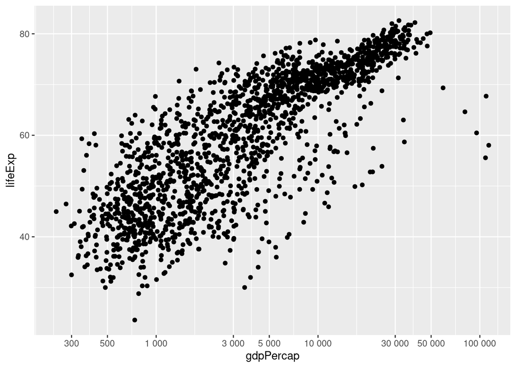

```r
gapminder %>%
  ggplot(aes(gdpPercap, lifeExp)) +
  geom_point() +
  scale_x_log10(labels = scales::label_number(),
                breaks = scales::log_breaks(n = 10))
```

I am intentionally leaving out words such as “correlation” here, because we have not properly defined it and will focus more on this in the second half of the course, where we use our R skills to dive into statistics.

- How did the population of the countries change over time? Make the plot more informative by adding color, facets and labels (with geom_text). Can you find out, how to add the country name label only to the last year? Hint: Have a look at the data argument that all geom_-functions have.

Note the usage of chunk options such as `fig.height` here:

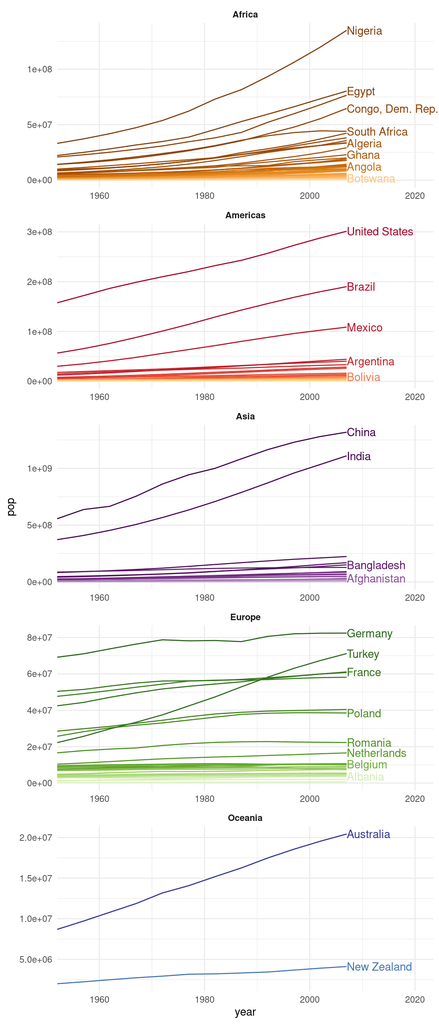

```r
gapminder %>%
  ggplot(aes(year, pop, group = country, color = country)) +
  geom_line() +
  geom_text(aes(label = country),
            data = filter(gapminder, year == max(year)),
            hjust = 0,
            check_overlap = TRUE) +
  facet_wrap(~continent, scales = "free", ncol = 1) +
  guides(color = "none") +
  scale_color_manual(values = country_colors) +
  scale_x_continuous(expand = expansion(mult = c(0, 0.3))) +
  coord_cartesian(clip = FALSE) +
  theme_minimal() +
  theme(strip.text = element_text(face = "bold"))
```